# As-a-Statistician-Time Series Analysis

Zehui Bai

2022-12-19 16:35:03

[interactive chart not shown]

## Fundational Concepts

The purpose of time series analysis is generally twofold: to understand or model the stochastic mechanism that gives rise to an observed series and to predict or forecast the future values of a series based on the history of that series and, possibly, other related series or factors.

### Means, Variances, and Covariances

For a stochastic process
$$\left\{Y_{t}: t=0, \pm 1, \pm 2, \pm 3, \ldots\right\},$$

The **autocovariance function**, $\gamma_{t, s}$, is defined as

$$\gamma_{t, s}=\operatorname{Cov}\left(Y_{t}, Y_{s}\right) \quad \text { for } t, s=0, \pm 1, \pm 2, \ldots$$

where
$$\operatorname{Cov}\left(Y_{t}, Y_{s}\right)=E\left[\left(Y_{t}-\mu_{t}\right)\left(Y_{s}-\mu_{s}\right)\right]=E\left(Y_{t} Y_{s}\right)-\mu_{t} \mu_{s}$$

The **autocorrelation function,** $\rho_{t, s}$, is given by

$$\rho_{t, s}=\operatorname{Corr}\left(Y_{t}, Y_{s}\right) \quad \text { for } t, s=0, \pm 1, \pm 2, \ldots$$

where

$$\operatorname{Corr}\left(Y_{t}, Y_{s}\right)=\frac{\operatorname{Cov}\left(Y_{t}, Y_{s}\right)}{\sqrt{\operatorname{Var}\left(Y_{t}\right) \operatorname{Var}\left(Y_{s}\right)}}=\frac{\gamma_{t, s}}{\sqrt{\gamma_{t, t} \gamma_{s, s}}}$$

The following important properties follow from known results and our definitions:

$$\left.\begin{array}{ll}
\gamma_{t, t}=\operatorname{Var}\left(Y_{t}\right) & \rho_{t, t}=1 \\
\gamma_{t, s}=\gamma_{s, t} & \rho_{t, s}=\rho_{s, t} \\
\left|\gamma_{t, s}\right| \leq \sqrt{\gamma_{t, t} \gamma_{s, s}} & \left|\rho_{t, s}\right| \leq 1
\end{array}\right\}$$

Values of $\rho_{t, s}$ near $\pm 1$ indicate strong (linear) dependence, whereas values near zero indicate weak (linear) dependence. If $\rho_{t, s}=0$, we say that $Y_{t}$ and $Y_{s}$ are uncorrelated.

### Properties of covariance

To investigate the covariance properties of various time series models, the following result will be used repeatedly: If $c_{1}, c_{2}, \ldots, c_{m}$ and $d_{1}, d_{2}, \ldots, d_{n}$ are constants and $t_{1}$, $t_{2}, \ldots, t_{m}$$ and $$s_{1}, s_{2}, \ldots, s_{n}$ are time points, then

$$\operatorname{Cov}\left[\sum_{i=1}^{m} c_{i} Y_{t_{i}}, \sum_{j=1}^{n} d_{j} Y_{s_{j}}\right]=\sum_{i=1}^{m} \sum_{j=1}^{n} c_{i} d_{j} \operatorname{Cov}\left(Y_{t_{i}}, Y_{s_{j}}\right)$$

As a special case, we obtain the well-known result

$$\operatorname{Var}\left[\sum_{i=1}^{n} c_{i} Y_{t_{i}}\right]=\sum_{i=1}^{n} c_{i}^{2} \operatorname{Var}\left(Y_{t_{i}}\right)+2 \sum_{i=2}^{n} \sum_{j=1}^{i-1} c_{i} c_{j} \operatorname{Cov}\left(Y_{t_{i}}, Y_{t_{j}}\right)$$
Forthermore:

$$\begin{array}{c}
\operatorname{Cov}(a+b X, c+d Y)=b d \operatorname{Cov}(X, Y) \\
\operatorname{Var}(X+Y)=\operatorname{Var}(X)+\operatorname{Var}(Y)+2 \operatorname{Cov}(X, Y) \\
\operatorname{Cov}(X+Y, Z)=\operatorname{Cov}(X, Z)+\operatorname{Cov}(Y, Z) \\
\operatorname{Cov}(X, X)=\operatorname{Var}(X) \\
\operatorname{Cov}(X, Y)=\operatorname{Cov}(Y, X)
\end{array}$$

If $X$ and $Y$ are independent,

$$\operatorname{Cov}(X, Y)=0$$

The correlation coefficient of $X$ and $Y$, denoted by $\operatorname{Cor}(X, Y)$ or $\rho$, is defined as

$$\rho=\operatorname{Corr}(X, Y)=\frac{\operatorname{Cov}(X, Y)}{\sqrt{\operatorname{Var}(X) \operatorname{Var}(Y)}}$$

Alternatively, if $X^{*}$ is a standardized $X$ and $Y^{*}$ is a standardized $Y$, then $\rho=E\left(X^{*} Y^{*}\right) .$

### Properties of Expectation

If $h(x)$ is a function such that $\int_{-\infty}^{\infty}|h(x)| f(x) d x<\infty$, it may be shown that

$$E[h(X)]=\int_{-\infty}^{\infty} h(x) f(x) d x$$

Similarly, if $\int_{-\infty}^{\infty} \int_{-\infty}^{\infty}|h(x, y)| f(x, y) d x d y<\infty$, it may be shown that

$$E[h(X, Y)]=\int_{-\infty}^{\infty} \int_{-\infty}^{\infty} h(x, y) f(x, y) d x d y$$

As a corollary, we easily obtain the important result

$$E(a X+b Y+c)=a E(X)+b E(Y)+c$$

We also have

$$E(X Y)=\int_{-\infty}^{\infty} \int_{-\infty}^{\infty} x y f(x, y) d x d y$$

The variance of a random variable $X$ is defined as

$$\operatorname{Var}(X)=E\left\{[X-E(X)]^{2}\right\}$$

(provided $E\left(X^{2}\right)$ exists). The variance of $X$ is often denoted by $\sigma^{2}$ or $\sigma_{X}^{2}$

### Properties of Variance

$$\begin{array}{c}
\operatorname{Var}(X) \geq 0 \\
\operatorname{Var}(a+b X)=b^{2} \operatorname{Var}(X)
\end{array}$$

If $X$ and $Y$ are independent, then

$$\operatorname{Var}(X+Y)=\operatorname{Var}(X)+\operatorname{Var}(Y)$$

In general, it may be shown that

$$\operatorname{Var}(X)=E\left(X^{2}\right)-[E(X)]^{2}$$

The positive square root of the variance of $X$ is called the standard deviation of $X$ and is often denoted by $\sigma$ or $\sigma_{X}$. The random variable $\left(X-\mu_{X}\right) / \sigma_{X}$ is called the standardized version of $X .$ The mean and standard deviation of a standardized variable are always zero and one, respectively. The covariance of $X$ and $Y$ is defined as $\operatorname{Cov}(X, Y)=E\left[\left(X-\mu_{X}\right)\left(Y-\mu_{Y}\right)\right]$.

### The Random Walk

Let $e_{1}, e_{2}, \ldots$ be a sequence of independent, identically distributed random variables each with zero mean and variance $\sigma_{e}^{2} .$ The observed time series, $\left\{Y_{t}: t=1,2, \ldots\right\}$, is constructed as follows:

$$\left.\begin{array}{rl}
Y_{1} & =e_{1} \\
Y_{2} & =e_{1}+e_{2} \\
& \vdots \\
Y_{t} & =e_{1}+e_{2}+\cdots+e_{t}
\end{array}\right\}$$

Alternatively, we can write

$$Y_{t}=Y_{t-1}+e_{t}$$

with “initial condition” $Y_{1}=e_{1} .$

#### The mean function is

$$\begin{aligned}
\mu_{t} &=E\left(Y_{t}\right)=E\left(e_{1}+e_{2}+\cdots+e_{t}\right)=E\left(e_{1}\right)+E\left(e_{2}\right)+\cdots+E\left(e_{t}\right) \\
&=0+0+\cdots+0
\end{aligned}$$

so that

$$\mu_{t}=0 \quad \text { for all } t$$

#### The variance function is

$$\begin{aligned}
\operatorname{Var}\left(Y_{t}\right) &=\operatorname{Var}\left(e_{1}+e_{2}+\cdots+e_{t}\right)=\operatorname{Var}\left(e_{1}\right)+\operatorname{Var}\left(e_{2}\right)+\cdots+\operatorname{Var}\left(e_{t}\right) \\
&=\sigma_{e}^{2}+\sigma_{e}^{2}+\cdots+\sigma_{e}^{2}
\end{aligned}$$

so that

$$\operatorname{Var}\left(Y_{t}\right)=t \sigma_{e}^{2}$$

#### The covariance function is

Notice that the process variance increases linearly with time. To investigate the covariance function, suppose that $1 \leq t \leq s .$ Then we have

$$\gamma_{t, s}=\operatorname{Cov}\left(Y_{t}, Y_{s}\right)=\operatorname{Cov}\left(e_{1}+e_{2}+\cdots+e_{t}, e_{1}+e_{2}+\cdots+e_{t}+e_{t+1}+\cdots+e_{s}\right)$$

From Equation above, we have

$$\gamma_{t, s}=\sum_{i=1}^{s} \sum_{j=1}^{t} \operatorname{Cov}\left(e_{i}, e_{j}\right)$$

However, these covariances are zero unless $i=j$, in which case they equal $\operatorname{Var}\left(e_{i}\right)=\sigma_{e}^{2}$. There are exactly $t$ of these so that $\gamma_{t, s}=t \sigma_{e}^{2}$.

#### The autocorrelation function

Since $\gamma_{t, s}=\gamma_{s, t}$, this specifies the autocovariance function for all time points $t$ and $s$ and we can write

$$\gamma_{t, s}=t \sigma_{e}^{2}$$

for $1 \leq t \leq s$ The autocorrelation function for the random walk is now easily obtained as

$$\rho_{t, s}=\frac{\gamma_{t, s}}{\sqrt{\gamma_{t, t} \gamma_{s, s}}}=\sqrt{\frac{t}{s}}$$

### A Moving Average

As a second example, suppose that $\left\{Y_{t}\right\}$ is constructed as

$$Y_{t}=\frac{e_{t}+e_{t-1}}{2}$$

where (as always throughout this book) the
$$e$$
’s are assumed to be independent and identically distributed with zero mean and variance $\sigma_{e}^{2} .$ Here

$$\begin{aligned}
\mu_{t} &=E\left(Y_{t}\right)=E\left\{\frac{e_{t}+e_{t-1}}{2}\right\}=\frac{E\left(e_{t}\right)+E\left(e_{t-1}\right)}{2} =0
\end{aligned}$$

$$\begin{aligned}
\operatorname{Var}\left(Y_{t}\right) &=\operatorname{Var}\left\{\frac{e_{t}+e_{t-1}}{2}\right\}=\frac{\operatorname{Var}\left(e_{t}\right)+\operatorname{Var}\left(e_{t-1}\right)}{4} \\
&=0.5 \sigma_{e}^{2}
\end{aligned}$$

$$\begin{aligned}
\operatorname{Cov}\left(Y_{t}, Y_{t-1}\right)=& \operatorname{Cov}\left\{\frac{e_{t}+e_{t-1}}{2}, \frac{e_{t-1}+e_{t-2}}{2}\right\} \\
=& \frac{\operatorname{Cov}\left(e_{t}, e_{t-1}\right)+\operatorname{Cov}\left(e_{t}, e_{t-2}\right)+\operatorname{Cov}\left(e_{t-1}, e_{t-1}\right)}{4}
+\frac{\operatorname{Cov}\left(e_{t-1}, e_{t-2}\right)}{4} \\
=& \frac{\operatorname{Cov}\left(e_{t-1}, e_{t-1}\right)}{4} \quad \text { (as all the other covariances are zero) } \\
=& 0.25 \sigma_{e}^{2}
\end{aligned}$$

Or

$$\gamma_{t, t-1}=0.25 \sigma_{e}^{2}$$

for all $t$. Furthermore,

$$\begin{aligned}
\operatorname{Cov}\left(Y_{t}, Y_{t-2}\right) &=\operatorname{Cov}\left\{\frac{e_{t}+e_{t-1}}{2}, \frac{e_{t-2}+e_{t-3}}{2}\right\} \\
&=0 \quad \text { since the } e^{\prime} \text { s are independent }
\end{aligned}$$

Similarly, $\operatorname{Cov}\left(Y_{t}, Y_{t-k}\right)=0$ for $k>1$, so we may write

$$\gamma_{t, s}=\left\{\begin{array}{cc}
0.5 \sigma_{e}^{2} & \text { for }|t-s|=0 \\
0.25 \sigma_{e}^{2} & \text { for }|t-s|=1 \\
0 & \text { for }|t-s|>1
\end{array}\right.$$

### Strictly Stationarity

一般而言，时间序列被看作一个随机过程${X_t}$，是一列随机变量

- 严平稳：多元分布保持不变。（X1,X2,X3)是个三维随机变量，（X3,X4,X5)也是个三维随机变量，严格平稳表示任何形如（Xn-1,Xn,Xn+1)的三维随机变量分布都是一样的。当然不仅仅是三维，而是任何维的随机变量分布不变。严平稳表示的分布不随时间的改变而改变。我研究第1到第n个随机变量跟第2到第n+1个随机变量性质是一样的。最简单的例子，白噪声（正态），无论怎么取，都是期望为0，方差为1，协方差都为0的n维正态分布。
- 弱平稳：首先要有个平稳的改变但是没有任何趋势，所以任何一点t，Xt的期望是常数（通常我们让他为0），弱平稳没有分布不于时间无关这个性质（**分布不随时间的改变而改变**），但是弱平稳抓住了另一个不变性——**相关系数**。这说明什么，X1于X3的相关系数， X2与X4的相关系数都是一样的，也就是 说相关系数取决于时间间隔而非时间起始点。这是非常重要的，因为回归是研究Y依赖于X的关系，可是单一时间序列只有X没有Y，未来某时刻的t的值Xt就要依赖于它的过去信息，如果没有依赖性将无法建立模型。 通常情况下时间序列分析讨论的是弱平稳序列。
1. 时间序列预处理：拿到一个观察值序列后，首先要对它的纯随机性和平稳性进行检验，这两个检验过程称之为序列的预处理。白噪声序列是没有信息可提取的平稳序列，没有进行序列分析的必要。
- 平稳性检验: **平稳即代表没有明显趋势且波动范围有限**, 定义：如果时间序列在某一常数附近波动且波动范围有限，即有常数均值和常数方差，并且延迟k期的序列变量的自协方差和自相关系数是相等的或者说延迟k期的序列变量之间的影响程度是一样的，则称该序列为平稳序列。
- 检验方法：
  - 时序图检验：根据平稳时间序列的均值和方差都为常数的性质，平稳序列的时序图显示该序列值始终在一个常数附近随机波动，而且波动的范围有界；如果有明显的趋势性或者周期性，那它通常不是平稳序列
  - 自相关图检验：平稳序列具有短期相关性，这个性质表明对平稳序列而言通常只有近期的序列值对现时值得影响比较明显，间隔越远的过去值对现时值得影响越小。随着延迟期数k的增加，平稳序列的自相关系数会比较快的衰减趋向于零，并在零附近随机波动，而非平稳序列的自相关系数衰减的速度比较慢。
  - 单位根检验。指的是是否存在单位根，如果存在单位根，即为非平稳时间序列
2. 按照下图进行判断

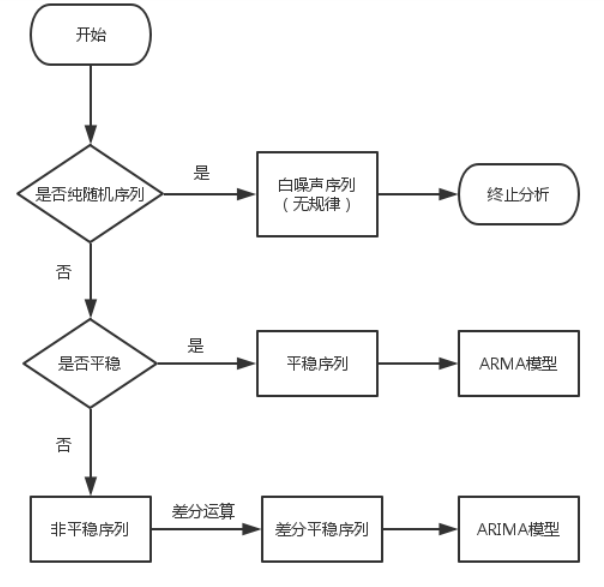

Thus, when $n=1$ the (univariate) distribution of $Y_{t}$ is the same as that of $Y_{t-k}$ for all $t$ and $k$; in other words, the $Y$ ’s are (marginally) identically distributed. It then follows that $E\left(Y_{t}\right)=E\left(Y_{t-k}\right)$ for all $t$ and $k$ so that the mean function is constant for all time. Additionally, $\operatorname{Var}\left(Y_{t}\right)=\operatorname{Var}\left(Y_{t-k}\right)$ for all $t$ and $k$ so that the variance is also constant over time.

Setting $n=2$ in the stationarity definition we see that the bivariate distribution of $Y_{t}$ and $Y_{s}$ must be the same as that of $Y_{t-k}$ and $Y_{s-k}$ from which it follows that $\operatorname{Cov}\left(Y_{t}, Y_{s}\right)$ $=\operatorname{Cov}\left(Y_{t-k}, Y_{s-k}\right)$ for all $t, s$, and $k$. Putting $k=s$ and then $k=t$, we obtain
$$\begin{aligned}
\gamma_{t, s} &=\operatorname{Cov}\left(Y_{t-s}, Y_{0}\right) \\
&=\operatorname{Cov}\left(Y_{0}, Y_{s-t}\right) \\
&=\operatorname{Cov}\left(Y_{0}, Y_{|t-s|}\right) \\
&=\gamma_{0,|t-s|}
\end{aligned}$$

That is, the covariance between $Y_{t}$ and $Y_{s}$ depends on time only through the time difference $|t-s|$ and not otherwise on the actual times $t$ and $s$. Thus, for a stationary process, we can simplify our notation and write
$$\gamma_{k}=\operatorname{Cov}\left(Y_{t}, Y_{t-k}\right) \quad \text { and } \quad \rho_{k}=\operatorname{Corr}\left(Y_{t}, Y_{t-k}\right)$$
Note also that
$$\rho_{k}=\frac{\gamma_{k}}{\gamma_{0}}$$
The general properties given in Equation now become
$$\left.\begin{array}{ll}
\gamma_{0}=\operatorname{Var}\left(Y_{t}\right) & \rho_{0}=1 \\
\gamma_{k}=\gamma_{-k} & \rho_{k}=\rho_{-k} \\
\left|\gamma_{k}\right| \leq \gamma_{0} & \left|\rho_{k}\right| \leq 1
\end{array}\right\}$$
If a process is strictly stationary and has finite variance, then the **covariance function must depend only on the time lag.**

### Weakly (or second-order) stationary

A stochastic process
$$\left\{Y_{t}\right\}$$
** is said to be weakly (or second-order) stationary if

1. **The mean function is constant over time, and**
2. for all time
   $$t$$
   and lag $k$

$$\gamma_{t, t-k}=\gamma_{0, k}$$

### White Noise

A very important example of a stationary process is the so-called white noise process, which is defined as a sequence of independent, identically distributed random variables $\left\{e_{t}\right\}$. Its importance stems not from the fact that it is an interesting model itself but from the fact that many useful processes can be constructed from white noise. The fact that $\left\{e_{t}\right\}$ is strictly stationary is easy to see since

$\operatorname{Pr}\left(e_{t_{1}} \leq x_{1}, e_{t_{2}} \leq x_{2}, \ldots, e_{t_{n}} \leq x_{n}\right)$ $=\operatorname{Pr}\left(e_{t_{1}} \leq x_{1}\right) \operatorname{Pr}\left(e_{t_{2}} \leq x_{2}\right) \cdots \operatorname{Pr}\left(e_{t_{n}} \leq x_{n}\right) \quad$ (by independence) $=\operatorname{Pr}\left(e_{t_{1}-k} \leq x_{1}\right) \operatorname{Pr}\left(e_{t_{2}-k} \leq x_{2}\right) \cdots \operatorname{Pr}\left(e_{t_{n}-k} \leq x_{n}\right)$ $=\operatorname{Pr}\left(e_{t_{1}-k} \leq x_{1}, e_{t_{2}-k} \leq x_{2}, \ldots, e_{t_{n}-k} \leq x_{n}\right)$ (identical distributions) (by independence)

as required. Also, $\mu_{t}=E\left(e_{t}\right)$ is constant and
$$\gamma_{k}=\left\{\begin{array}{cl}
\operatorname{Var}\left(e_{t}\right) & \text { for } k=0 \\
0 & \text { for } k \neq 0
\end{array}\right.$$
Alternatively, we can write
$$\rho_{k}=\left\{\begin{array}{ll}
1 & \text { for } k=0 \\
0 & \text { for } k \neq 0
\end{array}\right.$$
The term white noise arises from the fact that a frequency analysis of the model shows that, in analogy with white light, all frequencies enter equally. We usually assume that the white noise process has mean zero and denote $\operatorname{Var}\left(e_{t}\right)$ by $\sigma_{e}^{2}$.

The moving average example, $Y_{t}=\left(e_{t}+e_{t-1}\right) / 2$, is another example of a stationary process constructed from white noise. In our new notation, we have for the moving average process that
$$\rho_{k}=\left\{\begin{array}{ll}
1 & \text { for } k=0 \\
0.5 & \text { for }|k|=1 \\
0 & \text { for }|k| \geq 2
\end{array}\right.$$

### Deterministic Versus Stochastic Trends

In a general time series, the mean function is a totally arbitrary function of time. In a stationary time series, the mean function must be constant in time. Frequently we need to take the middle ground and consider mean functions that are relatively simple (but not constant) functions of time.

We might assume that $X_{t}$, the unobserved variation around $\mu_{t}$, has zero mean for all $t$ so that indeed $\mu_{t}$ is the mean function for the observed series $Y_{t} .$ We could describe this model as having a deterministic trend as opposed to the stochastic trend considered earlier. In other situations we might hypothesize a deterministic trend that is linear in time (that is, $\left.\mu_{t}=\beta_{0}+\beta_{1} t\right)$ or perhaps a quadratic time trend, $\mu_{t}=\beta_{0}+\beta_{1} t+\beta_{2} t^{2}$. Note that an implication of the model $Y_{t}=\mu_{t}+X_{t}$ with $E\left(X_{t}\right)=0$ for all $t$ is that the deterministic trend $\mu_{t}$ applies for all time. Thus, if $\mu_{t}=\beta_{0}+\beta_{1} t$, we are assuming that the same linear time trend applies forever. We should therefore have good reasons for assuming such a model-not just because the series looks somewhat linear over the time period observed.

## ARMA models

> MODELS FOR STATIONARY TIME SERIES

### General Linear Processes

A general linear process, $\left\{Y_{t}\right\}$, is one that can be represented as a weighted linear combination of present and past white noise terms as
$$Y_{t}=e_{t}+\psi_{1} e_{t-1}+\psi_{2} e_{t-2}+\cdots$$
If the right-hand side of this expression is truly an infinite series, then certain conditions must be placed on the $\psi$-weights for the right-hand side to be meaningful mathematically. For our purposes, it suffices to assume that
$$\sum_{i=1}^{\infty} \psi_{i}^{2}<\infty$$
We should also note that since $\left\{e_{t}\right\}$ is unobservable, there is no loss in the generality of Equation (4.1.2) if we assume that the coefficient on $e_{t}$ is 1 ; effectively, $\psi_{0}=1$

- $\left\{Y_{t}\right\}$ denote the observed time series.
- $\left\{e_{t}\right\}$ represent an unobserved white noise series, that is, a sequence of identically distributed, zero-mean, independent random variables.
- the assumption of independence could be replaced by the weaker assumption that the $\left\{e_{t}\right\}$ are uncorrelated random variables

An important nontrivial example to which we will return often is the case where the $\psi$ is form an exponentially decaying sequence
$$\psi_{j}=\phi^{j}$$
where $\phi$ is a number strictly between $-1$ and $+1$. Then
$$Y_{t}=e_{t}+\phi e_{t-1}+\phi^{2} e_{t-2}+\cdots$$
For this example,
$$E\left(Y_{t}\right)=E\left(e_{t}+\phi e_{t-1}+\phi^{2} e_{t-2}+\cdots\right)=0$$

so that $\left\{Y_{t}\right\}$ has a constant mean of zero. Also,
$$\begin{aligned}
\operatorname{Var}\left(Y_{t}\right) &=\operatorname{Var}\left(e_{t}+\phi e_{t-1}+\phi^{2} e_{t-2}+\cdots\right) \\
&=\operatorname{Var}\left(e_{t}\right)+\phi^{2} \operatorname{Var}\left(e_{t-1}\right)+\phi^{4} \operatorname{Var}\left(e_{t-2}\right)+\cdots \\
&=\sigma_{e}^{2}\left(1+\phi^{2}+\phi^{4}+\cdots\right) \\
&=\frac{\sigma_{e}^{2}}{1-\phi^{2}} \text { (by summing a geometric series) }
\end{aligned}$$
Furthermore,
$$\begin{aligned}
\operatorname{Cov}\left(Y_{t}, Y_{t-1}\right) &=\operatorname{Cov}\left(e_{t}+\phi e_{t-1}+\phi^{2} e_{t-2}+\cdots, e_{t-1}+\phi e_{t-2}+\phi^{2} e_{t-3}+\cdots\right) \\
&=\operatorname{Cov}\left(\phi e_{t-1}, e_{t-1}\right)+\operatorname{Cov}\left(\phi^{2} e_{t-2}, \phi e_{t-2}\right)+\cdots \\
&=\phi \sigma_{e}^{2}+\phi^{3} \sigma_{e}^{2}+\phi^{5} \sigma_{e}^{2}+\cdots \\
&=\phi \sigma_{e}^{2}\left(1+\phi^{2}+\phi^{4}+\cdots\right) \\
&=\frac{\phi \sigma_{e}^{2}}{1-\phi^{2}} \text { (again summing a geometric series) }
\end{aligned}$$
Thus
$$\operatorname{Corr}\left(Y_{t}, Y_{t-1}\right)=\left[\frac{\phi \sigma_{e}^{2}}{1-\phi^{2}}\right] /\left[\frac{\sigma_{e}^{2}}{1-\phi^{2}}\right]=\phi$$
In a similar manner, we can find $\operatorname{Cov}\left(Y_{t}, Y_{t-k}\right)=\frac{\phi^{k} \sigma_{e}^{2}}{1-\phi^{2}}$ and thus
$$\operatorname{Corr}\left(Y_{t}, Y_{t-k}\right)=\phi^{k}$$

**The process defined in this way is stationary—the autocovariance structure depends only on time lag and not on absolute time**